# SimulationExercises

martinvanelp

Sunday, September 21, 2014

## Simulation exercises

The exponential distribution can be simulated in R with rexp(n, lambda) where lambda is the rate parameter. The mean of exponential distribution is 1/lambda and the standard deviation is also also 1/lambda. Set lambda = 0.2 for all of the simulations. In this simulation, you will investigate the distribution of averages of 40 exponential(0.2)s. Note that you will need to do a thousand or so simulated averages of 40 exponentials.

Illustrate via simulation and associated explanatory text the properties of the distribution of the mean of 40 exponential(0.2)s. You should 1. Show where the distribution is centered at and compare it to the theoretical center of the distribution. 2. Show how variable it is and compare it to the theoretical variance of the distribution. 3. Show that the distribution is approximately normal. 4. Evaluate the coverage of the confidence interval for 1/lambda: X +/- 1.96S / sqrt(n).

## Output

**Initialize lambda, number of exponentials per sample, and number of simulations.**

```r
set.seed(123)
lambda <- 0.2
n <- 40
B <- 1000
```

**1. Show where the distribution is centered at and compare it to the theoretical center of the distribution.**

```r
samples <- matrix(sapply(1:B, function(i) rexp(n, lambda)), B, n)
means <- apply(samples, 1, mean)
c(mean(means), 1 / lambda)
```

```
## [1] 5.012 5.000
```

The mean in the simulation is slightly higher than the theoretical mean.

**2. Show how variable it is and compare it to the theoretical variance of the distribution.**

```r
sds <- apply(samples, 1, sd)
c(mean(sds), 1/lambda)
```

```
## [1] 4.877 5.000
```

The standard deviation is somewhat lower than the theoretical standard deviation.

**3. Show that the distribution is approximately normal.**

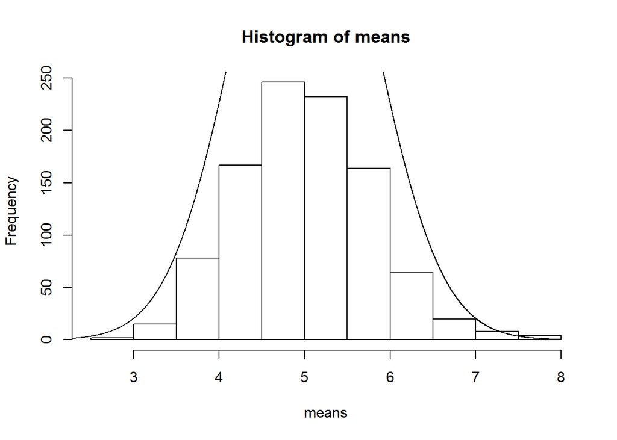

```r
hist(means)
zvals <- seq(2, 8, length = 10000)
lines(zvals, B * dnorm(zvals, mean = 1/lambda, sd = 1/lambda / sqrt(n)))
```

**4. Evaluate the coverage of the confidence interval for 1/lambda: X +/- 1.96S / sqrt(n).**

```r
coverage <- sapply(1:1000, function(i) {
        ll <- means[i] - qnorm(0.975) * sds[i] / sqrt(n)
        ul <- means[i] + qnorm(0.975) * sds[i] / sqrt(n)
        ll < 1/lambda & ul > 1/lambda
})
mean(coverage)
```

```
## [1] 0.926
```

The coverage is almost 93%, with this seed.